# 3장. 군집분석

```r
# credit card
credit <- read.csv('german_credit.csv')
credit$Creditability <- as.factor(credit$Creditability)

set.seed(1)
idx <- sample(1:nrow(credit),nrow(credit)*0.7,replace=F)
train <- credit[idx,]
test <- credit[-idx,]
```

### 1절. 군집분석

#### 1. 개요

유사성이 높은 대상 집단을 분류, 군집이 속한 객체들의 유사성과 서로 다른 군집에 속한 객체 간의 상이성을 규명하는 분석 방법

#### 2. 특징

- 요인분석과 차이점 : 요인분석은 유사한 변수를 함께 묶어줌
- 판별분석과 차이점 : 사전에 집단이 나누어져 있는 자료를 통해 새로운 데이터를 기존의 집단에 할당

#### 3. 거리

i. 연속형 변수

- 유클리디안 거리

  $$d(x,y)=\sqrt{(x_1-y_1)^2+\cdots+(x_p-y_p)^2}$$
- 표준화 거리

  $$d(x,y) = \sqrt{(x-y)^`D^{-1}(x-y)} \; , \quad D =
  diag\{s_{11},...,s_{pp}\}$$
- 마할라노비스 거리

  $$d(x,y)=\sqrt{(x-y)^`S^{-1}(x-y)}\; , \quad S=\{S_{ij}\}는 \, 공분산행렬$$
- 체비셰프 거리

  $$d(x,y)=max_i|x_i-y_i|$$
- 맨하탄 거리

  $$d(x,y) = \sum^p_{i=1} |x_i-y_i|$$
- 캔버라 거리

  $$d(x,y)=\sum^p_{i=1} \frac{|x_i-y_i|}{(x_i+y_i)}$$
- 민코우스키 거리

  $$d(x,y)=[\sum^p_{i=1}|x_i-y_i|^m]^{1/m} \quad m=1 \; or\; 2$$

ii. 범주형 변수

- 자카드 거리

  $$1-J(A,B)=\frac{|A \cup B|-|A \cap B|}{|A \cup B|}$$
- 자카드 계수

  $$J(A,B)=\frac{|A \cap B|}{|A \cup B|}$$
- 코사인 유사도

  $$cosine \; similarity = 1-\frac{A \bullet B}{||A||_2 \bullet ||B||_2}$$

### 2절. 계층적 군집분석

: n개의 군집으로 시작해 점차 군집의 개수를 줄여 나가는 방법

#### 1. 계충적 군집분석 종류

1. 최단연결법
2. 최장연결법
3. 평균연결법
4. 와드연결법
5. 군집화

##### R

- dist(data, method)
  - method : 거리측정 방법(‘euclidean’,‘maximum’,‘manhattan’,‘canberra’,binary’,‘minkowski’)
- hclust(data, method)
  - data : dist 함수로 거리가 측정된 데이터
  - method : 거리측정 방법 (‘single’,‘complete’,‘average’,‘median’,‘ward.D’)

```r
data("USArrests")
head(USArrests)
```

```
##            Murder Assault UrbanPop Rape
## Alabama      13.2     236       58 21.2
## Alaska       10.0     263       48 44.5
## Arizona       8.1     294       80 31.0
## Arkansas      8.8     190       50 19.5
## California    9.0     276       91 40.6
## Colorado      7.9     204       78 38.7
```

```r
# dist 함수
US.dist <- dist(USArrests, 'euclidean')
US.dist
```

```
##                   Alabama     Alaska    Arizona   Arkansas California
## Alaska          37.177009
## Arizona         63.008333  46.592489
## Arkansas        46.928137  77.197409 108.851918
## California      55.524769  45.102217  23.194180  97.582017
## Colorado        41.932565  66.475935  90.351148  36.734861  73.197131
## Connecticut    128.206942 159.406556 185.159526  85.028289 169.277110
## Delaware        16.806249  45.182961  58.616380  53.010376  49.291480
## Florida        102.001618  79.974496  41.654532 148.735739  60.980735
## Georgia         25.841827  57.030255  86.037957  25.586129  73.997297
## Hawaii         191.803050 221.193535 248.268967 147.775979 231.071093
## Idaho          116.761980 146.484982 176.817674  70.587038 162.612792
## Illinois        28.454877  42.911653  45.697812  67.770274  32.718802
## Indiana        123.345207 152.804090 181.897801  78.478086 166.229961
## Iowa           180.610105 209.983523 239.991458 134.594948 224.634659
## Kansas         121.519875 151.480197 180.028914  76.753436 164.516747
## Kentucky       127.284170 156.612037 187.690303  81.092848 173.207910
## Louisiana       15.454449  32.348879  48.494639  61.545512  41.635562
## Maine          154.145289 183.897526 214.327413 107.850730 199.931113
## Maryland        64.993615  44.839492  15.015991 111.642913  36.347352
## Massachusetts   91.648513 123.254209 145.875906  54.181178 129.524708
## Michigan        28.485435  28.857755  39.872422  71.100281  27.746351
## Minnesota      164.650964 194.253571 223.088256 119.324641 207.222537
## Mississippi     27.390144  28.635118  52.708728  69.685364  55.683570
## Missouri        59.788293  89.306719 116.467377  24.894377 100.988910
## Montana        127.392621 156.673578 187.540849  81.163107 172.996069
## Nebraska       134.436974 164.114259 193.423602  88.978930 178.100814
## Nevada          37.430469  34.886817  44.797433  74.288694  26.746962
## New Hampshire  179.736196 209.254415 239.255616 133.678308 224.055395
## New Jersey      83.243018 114.735566 135.850396  49.844257 119.041169
## New Mexico      51.643489  33.521933  13.896043  97.931200  24.495102
## New York        33.710829  43.182983  40.853519  73.762118  26.900929
## North Carolina 101.961022  79.376067  57.619615 147.184238  80.332123
## North Dakota   192.416138 221.378590 252.808188 145.855545 238.214462
## Ohio           117.387606 147.373335 174.338177  74.369752 157.998513
## Oklahoma        85.848704 116.429421 143.931407  43.012673 128.779346
## Oregon          78.386861 106.930117 135.672879  36.895122 120.039577
## Pennsylvania   131.085087 161.600897 188.866222  86.990862 172.999364
## Rhode Island    70.338112 103.903802 122.418871  42.185305 107.213106
## South Carolina  44.182915  27.556487  36.890920  89.248866  47.061343
```

[output cut: 445 more lines]

```
## Oklahoma
## Oregon
## Pennsylvania
## Rhode Island
## South Carolina
## South Dakota
## Tennessee
## Texas
## Utah
## Vermont
## Virginia
## Washington      16.477257
## West Virginia   79.616581  74.434535
## Wisconsin      103.686161  93.552766     39.049456
## Wyoming          7.930952  23.349518     82.957218 108.354418
```

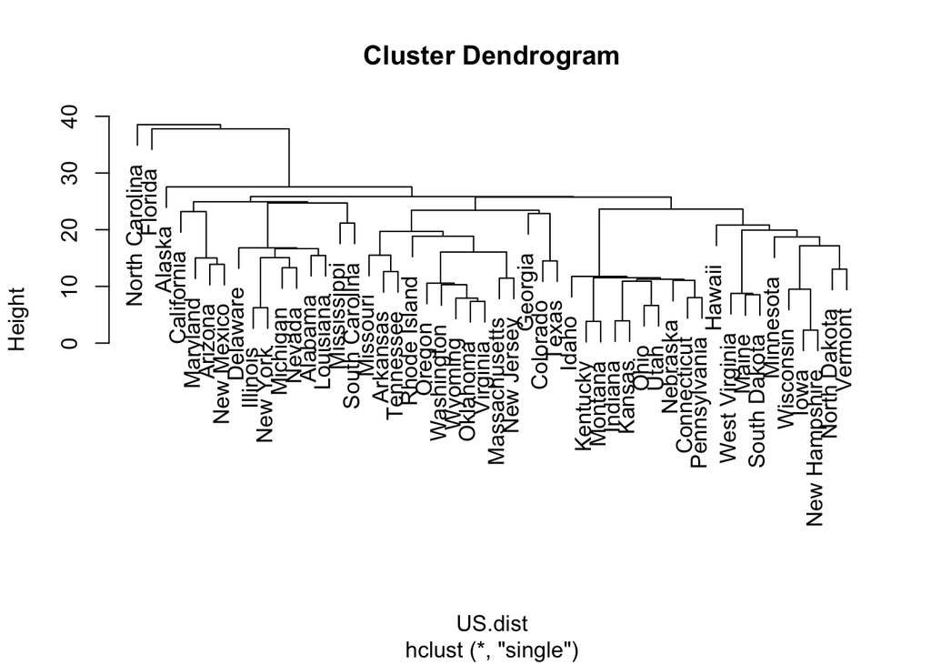

```r
# hclust 함수
## 1. 최단거리법
US.single <- hclust(US.dist, method = 'single')
plot(US.single) # 덴드로그램
```

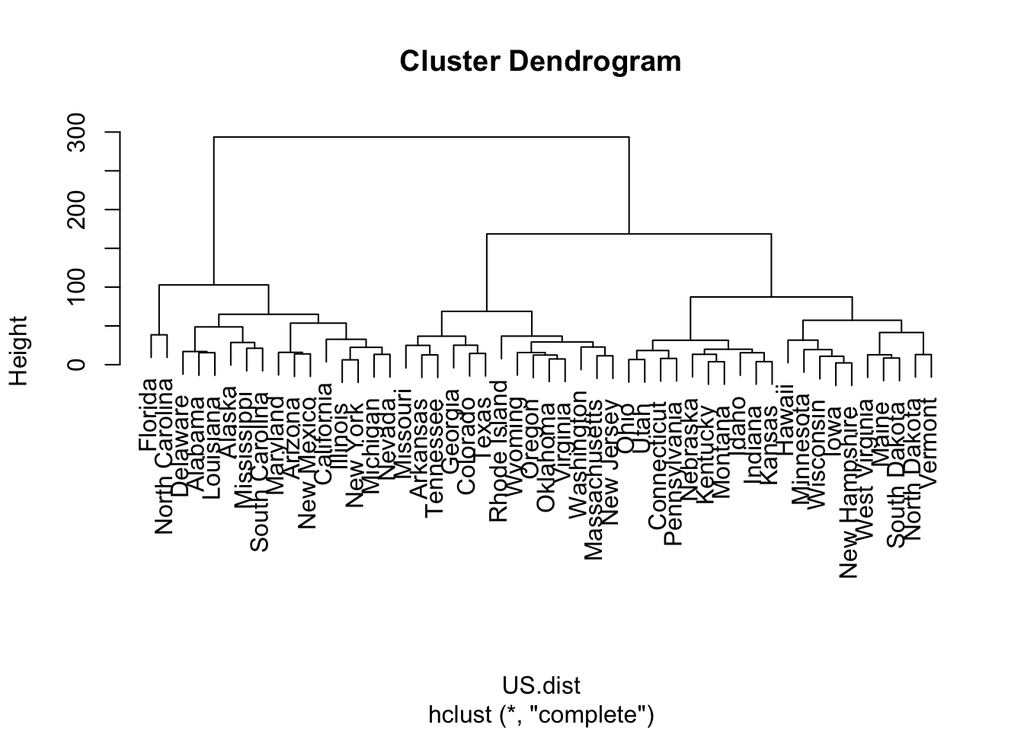

```r
## 2. 최장거리법
US.complete <- hclust(US.dist, method = 'complete')
plot(US.complete)
```

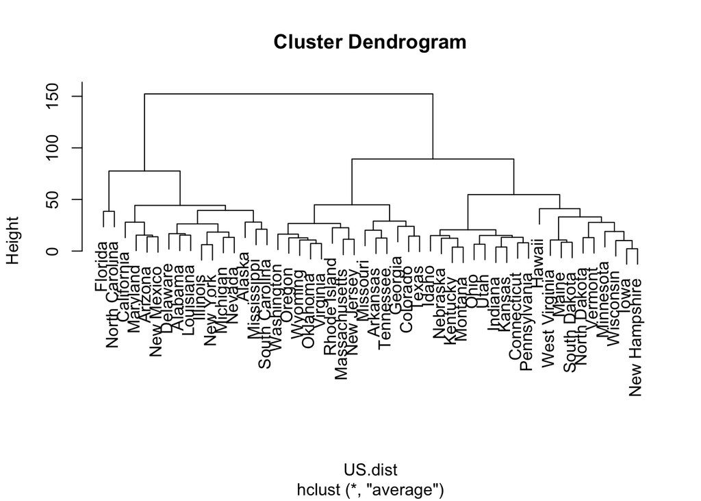

```r
## 3. 평균거리법
US.average <- hclust(US.dist, method = 'average')
plot(US.average)
```

※ cutree함수 : 계층적 군집의 결과를 이용하여 tree의 높이(h)나 그룹의 수(k)를 옵션으로 지정

```r
group <- cutree(US.average, k=6)
group
```

```
##        Alabama         Alaska        Arizona       Arkansas     California
##              1              1              1              2              1
##       Colorado    Connecticut       Delaware        Florida        Georgia
##              2              3              1              4              2
##         Hawaii          Idaho       Illinois        Indiana           Iowa
##              5              3              1              3              5
##         Kansas       Kentucky      Louisiana          Maine       Maryland
##              3              3              1              5              1
##  Massachusetts       Michigan      Minnesota    Mississippi       Missouri
##              6              1              5              1              2
##        Montana       Nebraska         Nevada  New Hampshire     New Jersey
##              3              3              1              5              6
##     New Mexico       New York North Carolina   North Dakota           Ohio
##              1              1              4              5              3
##       Oklahoma         Oregon   Pennsylvania   Rhode Island South Carolina
##              6              6              3              6              1
##   South Dakota      Tennessee          Texas           Utah        Vermont
##              5              2              2              3              5
##       Virginia     Washington  West Virginia      Wisconsin        Wyoming
##              6              6              5              5              6
```

※ rect.hclust함수 : plot함수를 통한 그래프에서 각각의 그룹을 사각형으로 구분지어 나타냄

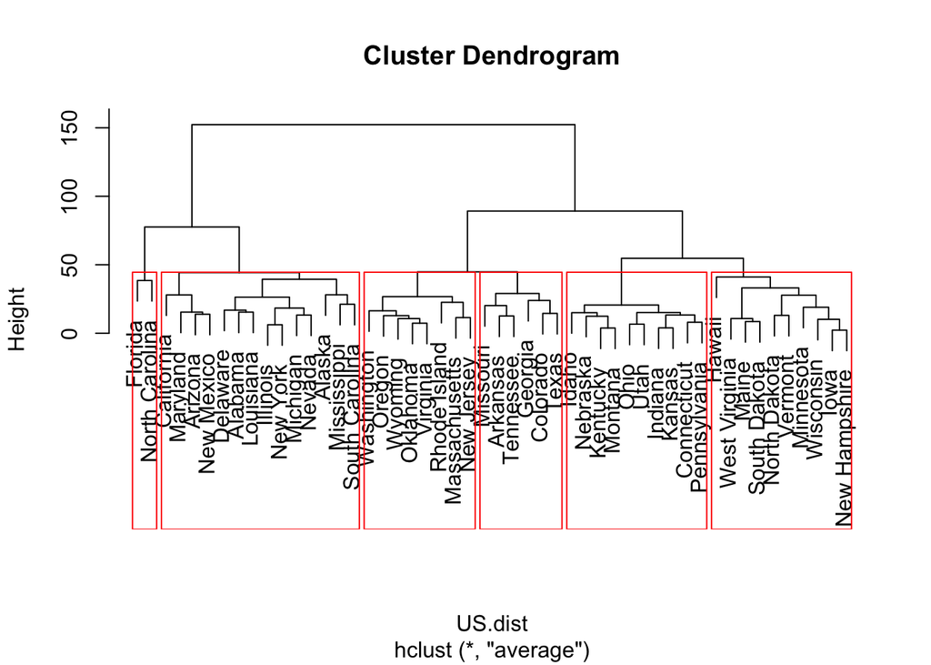

```r
plot(US.average)
rect.hclust(US.average,k=6,border = 'red')
```

### 3절. 비계층적 군집분석

#### 1. 개요

n개의 개체를 k개의 군집으로 나누어 모든 가능한 방법을 점검해 최적화한 군집 형성

#### 2. K-평균 군집분석(k-means clustering)

- 방법
  1. 원하는 군집의 개수와 초기 값(seed)들을 정해 seed 중심으로 군집 형성
  2. 각 데이터를 거리가 가장 가까운 seed가 있는 군집으로 분류
  3. 각 군집의 seed 값 다시 계산

##### R

- kmeans(data,centers,…)
  - centers : 군집의 개수 설정
- **Nbclust(data, min.nc. max.nc, method,…)\**

  최적의 k 선정
  - min.nc : 최소 군집의 수
  - max.nc : 최대 군집의 수
  - method : 군집분석 방법 (‘kmeans’,‘median’,‘single’,‘complete’,‘average’)

```r
train.data <- train[,-1]
credit.kmeans <- kmeans(train.data, centers = 2)
credit.kmeans
```

```
## K-means clustering with 2 clusters of sizes 123, 577
##
## Cluster means:
##   Account.Balance Duration.of.Credit..month. Payment.Status.of.Previous.Credit
## 1        2.536585                   34.94309                          2.487805
## 2        2.549393                   17.83189                          2.604853
##    Purpose Credit.Amount Value.Savings.Stocks Length.of.current.employment
## 1 3.097561      8383.902             2.349593                     3.430894
## 2 2.677643      2169.965             2.081456                     3.355286
##   Instalment.per.cent Sex...Marital.Status Guarantors
## 1            2.430894             2.707317   1.081301
## 2            3.062392             2.679376   1.150780
##   Duration.in.Current.address Most.valuable.available.asset Age..years.
## 1                    2.918699                      2.975610    37.65854
## 2                    2.883882                      2.227036    35.61352
```

[output cut: 87 more lines]

```r
# 정분류율
kmeans.table <- table(train$Creditability, credit.kmeans$cluster)
kmeans.table
```

```
##
##       1   2
##   0  53 163
##   1  70 414
```

```r
(kmeans.table[1,1] + kmeans.table[2,2])/sum(kmeans.table)
```

```
## [1] 0.6671429
```

※ 전체 변동에서 군집 간 변동이 차지하는 비율(between_SS / total_SS)이 1에 가까울수록 잘 군집화

=> between_SS / total_SS = 69.2%이므로 좋은 모델이라고 할 수 없다.

=> 정분류율 0.6671이므로 좋은 성능을 가지지 않았다고 판단

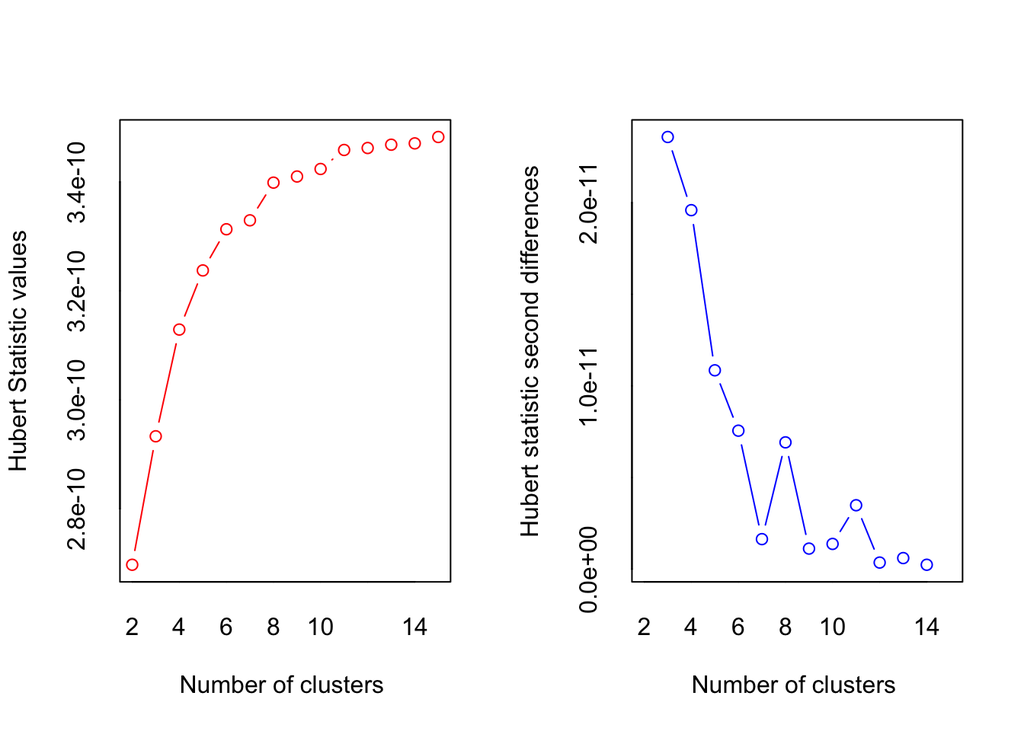

```
## *** : The Hubert index is a graphical method of determining the number of clusters.
##                 In the plot of Hubert index, we seek a significant knee that corresponds to a
##                 significant increase of the value of the measure i.e the significant peak in Hubert
##                 index second differences plot.
##
```

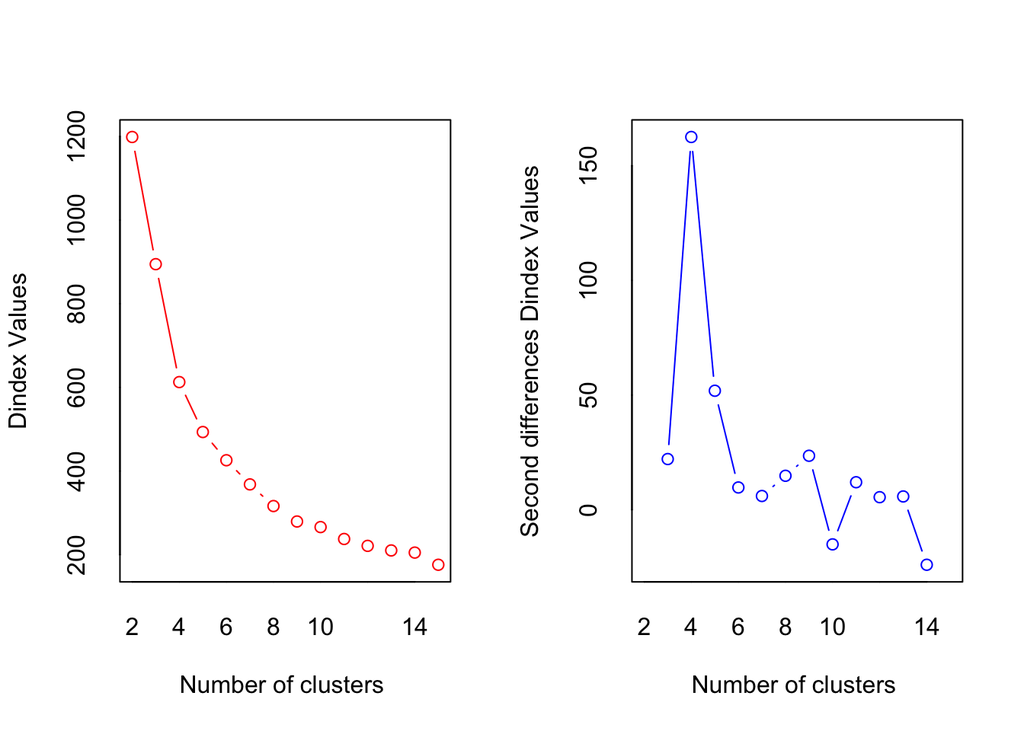

```
## *** : The D index is a graphical method of determining the number of clusters.
##                 In the plot of D index, we seek a significant knee (the significant peak in Dindex
##                 second differences plot) that corresponds to a significant increase of the value of
##                 the measure.
##
## * Among all indices:
## * 5 proposed 2 as the best number of clusters
## * 5 proposed 3 as the best number of clusters
## * 5 proposed 4 as the best number of clusters
## * 1 proposed 6 as the best number of clusters
## * 1 proposed 10 as the best number of clusters
## * 3 proposed 11 as the best number of clusters
## * 4 proposed 15 as the best number of clusters
##
##                    ***** Conclusion *****
##
## * According to the majority rule, the best number of clusters is  2
##
##
```

```r
# NbClust함수 =>
#install.packages('NbClust')
library(NbClust)

nc <- NbClust(train.data, min.nc = 2, max.nc = 15, method = 'kmeans')
```

### 4절. 혼합 분포 군집

#### 1. 개요

모형 기반의 군집 방법, 데이터가 k개의 모수적 모형의 가중합으로 표현되는 모집단 모형으로부터 나왔다는 가정하에서 모수와 가중치 추정

#### 2. 혼합 분모모형으로 설명할 수 있는 데이터의 형태

#### 3. EM(Expectation-Maximization) 알고리즘의 진행 과정

- E-단계 : 잠재변수 Z의 기대치 계산
- M-단계 : 잠재변수 Z의 기대치를 이용하여 파라미터 추정

#### 4. EM 알고리즘의 진행 과정

#### 5. R을 이용한 혼합 분포 군집분석 (mclust 패키지)

- Mclust(data, G, …)
  - data : 분석하고자 하는 데이터(수치형 변수만)
  - G : BIC를 계산할 혼합분포 클러스터의 수를 지정 (default = 1:9)

```r
#install.packages('mclust')
library(mclust)
mc <- Mclust(iris[,1:4],G=3)
summary(mc,parameters = T)
```

```
## ----------------------------------------------------
## Gaussian finite mixture model fitted by EM algorithm
## ----------------------------------------------------
##
## Mclust VEV (ellipsoidal, equal shape) model with 3 components:
##
##  log-likelihood   n df       BIC       ICL
##        -186.074 150 38 -562.5522 -566.4673
##
## Clustering table:
##  1  2  3
## 50 45 55
##
## Mixing probabilities:
##         1         2         3
## 0.3333333 0.3005423 0.3661243
##
## Means:
##               [,1]     [,2]     [,3]
## Sepal.Length 5.006 5.915044 6.546807
## Sepal.Width  3.428 2.777451 2.949613
## Petal.Length 1.462 4.204002 5.482252
## Petal.Width  0.246 1.298935 1.985523
##
## Variances:
## [,,1]
##              Sepal.Length Sepal.Width Petal.Length Petal.Width
## Sepal.Length   0.13320850  0.10938369  0.019191764 0.011585649
## Sepal.Width    0.10938369  0.15495369  0.012096999 0.010010130
## Petal.Length   0.01919176  0.01209700  0.028275400 0.005818274
## Petal.Width    0.01158565  0.01001013  0.005818274 0.010695632
## [,,2]
##              Sepal.Length Sepal.Width Petal.Length Petal.Width
## Sepal.Length   0.22572159  0.07613348   0.14689934  0.04335826
## Sepal.Width    0.07613348  0.08024338   0.07372331  0.03435893
## Petal.Length   0.14689934  0.07372331   0.16613979  0.04953078
## Petal.Width    0.04335826  0.03435893   0.04953078  0.03338619
## [,,3]
##              Sepal.Length Sepal.Width Petal.Length Petal.Width
## Sepal.Length   0.42943106  0.10784274   0.33452389  0.06538369
## Sepal.Width    0.10784274  0.11596343   0.08905176  0.06134034
## Petal.Length   0.33452389  0.08905176   0.36422115  0.08706895
## Petal.Width    0.06538369  0.06134034   0.08706895  0.08663823
```

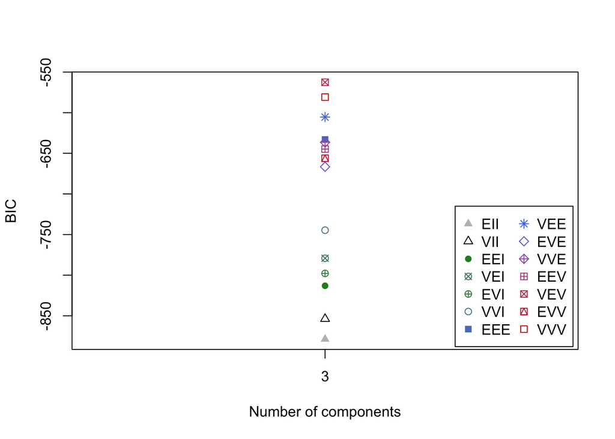

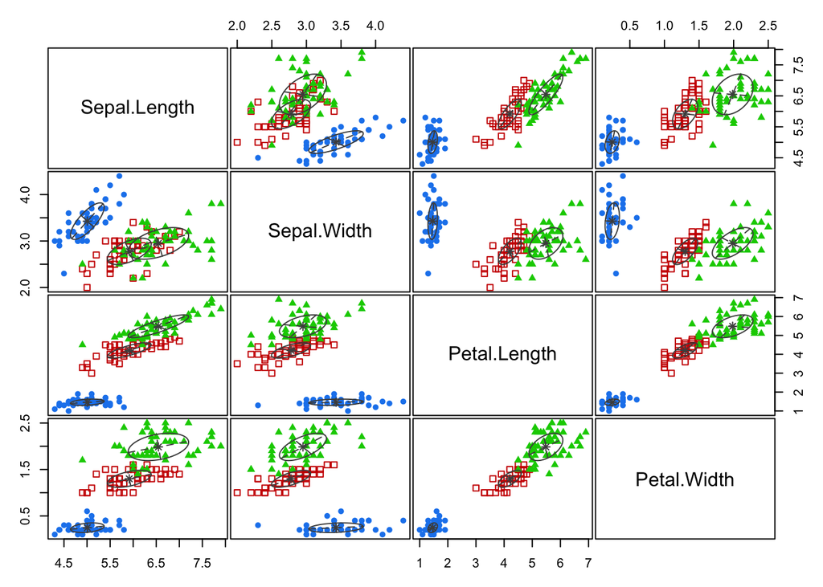

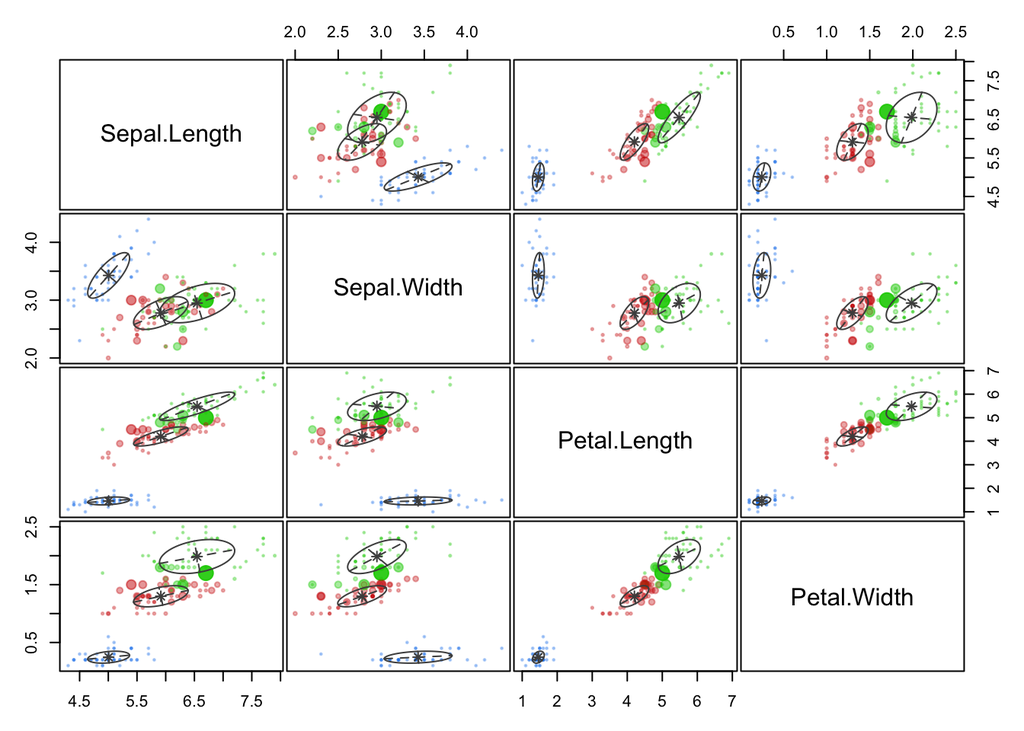

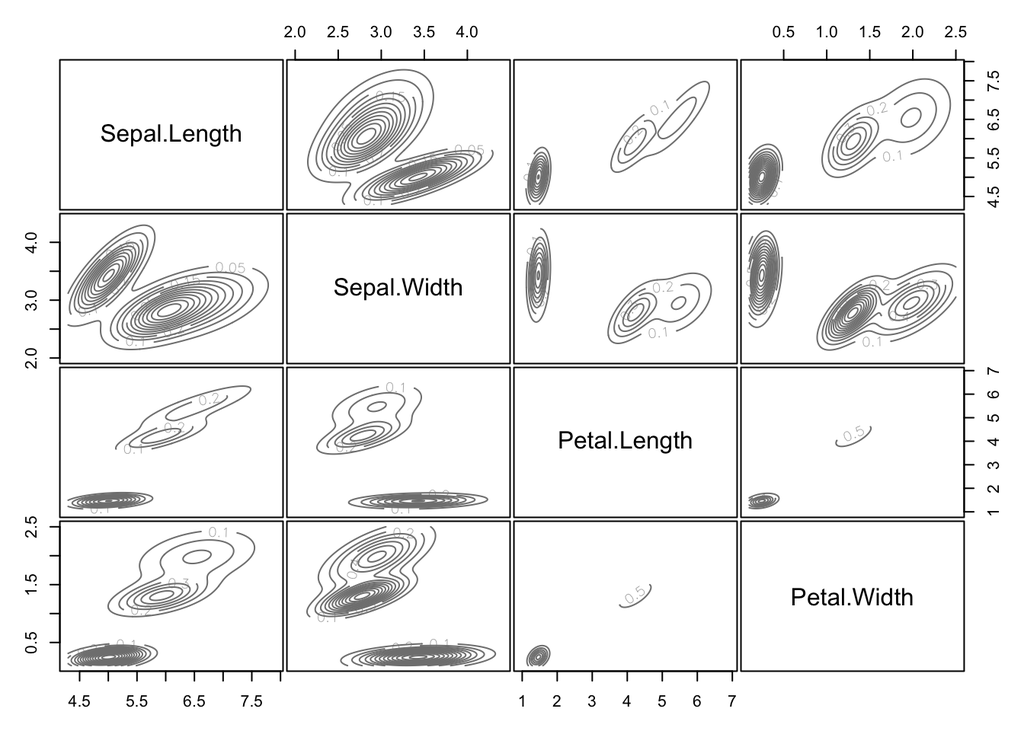

```r
# 시각화
plot.Mclust(mc)
```